# Análisis de expresión diferencial SFI vs NIT

# librerias usadas

```r
library(tidyverse); library(DESeq2); library(apeglm); library(Cairo); library(pheatmap); library(EnhancedVolcano); library(clusterProfiler); library(enrichplot); library(pathview)
library(AnnotationDbi); library(org.Hs.eg.db)
```

# Preparación del análisis de expresión de SFI vs NIT

A partir de los datos normalizados con DESeq2 se extraen los resultados de las comparaciones dos a dos, para hacer las comparaciones se pone en el numerador el mayor grado de infiltración (ELI>SFI>NIT), de forma que cuando los genes sobreexpresados serán aquellos que se expresen mas en la muestra con mayor infiltración, en este comparación, los genes sobreexpresados serán los más transcritos en las muestras SFI.

## Filtrado

Se filtran los genes por el fold change (parámetro lfcThreshold) y por el valor de significación (el parámentro alpha). El filtrado por defecto acepta como genes diferencialmente expresados cualquiera que tenga un p-valor menor de 0.1:

```r
load("materiales intermedios/dds_raw.Rda")

FC <- 1.5; alpha <- 0.05
sfi_nit <- results(dds, contrast=c("Group", "SFI", "NIT"), alpha = alpha)
sfi_nit_ashr <- lfcShrink(dds, contrast=c("Group", "SFI", "NIT"), type = "ashr", res=sfi_nit) # Con ashr shrink
```

```
using 'ashr' for LFC shrinkage. If used in published research, please cite:
    Stephens, M. (2016) False discovery rates: a new deal. Biostatistics, 18:2.
    https://doi.org/10.1093/biostatistics/kxw041
```

```r
summary(sfi_nit_ashr)
```

```
out of 43224 with nonzero total read count
adjusted p-value < 0.05
LFC > 0 (up)       : 466, 1.1%
LFC < 0 (down)     : 96, 0.22%
outliers [1]       : 0, 0%
low counts [2]     : 13411, 31%
(mean count < 1)
[1] see 'cooksCutoff' argument of ?results
[2] see 'independentFiltering' argument of ?results
```

```r
(p <- EnhancedVolcano(sfi_nit_ashr, FCcutoff = FC, lab = "", x = 'log2FoldChange',
                pCutoff = alpha, y = 'pvalue', title = "Volcano SFI vs NIT",
                subtitle = paste0("Genes diferencialmente expresados: ",
                                  sum((sfi_nit_ashr$padj < alpha)& abs(sfi_nit_ashr$log2FoldChange)>FC, na.rm=T)),
                gridlines.major = F, gridlines.minor = F))

dir.create("resultados/SFI vs NIT")
```

```
'resultados\SFI vs NIT' already exists
```

```r
dir.create("resultados/SFI vs NIT/imagenes")
```

```
'resultados\SFI vs NIT\imagenes' already exists
```

```r
cairo_pdf("resultados/SFI vs NIT/Volcano.pdf")
```

```r
p
dev.off()
```

```r
png("resultados/SFI vs NIT/imagenes/Volcano.png", height = 1500, width = 2000, res=200)
p
```

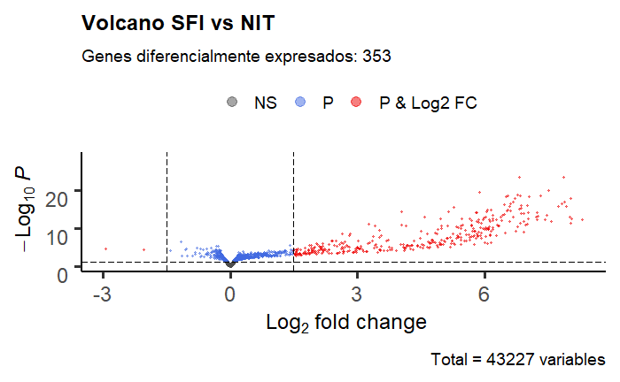

```r
dev.off()
```

Los genes elegidos son los marcados en rojo, son 353 de un total de 43227, lo que supone el 0.82%.

Son muchísimos menos genes expresados diferencialmente que en la comparación ELIvsNIT, además la distribución de p-valores no tiene tantos valores cercanos a 0, esto es esperable porque la diferencia fenotípica entre SFI y NIT es menor que entre ELI y NIT.

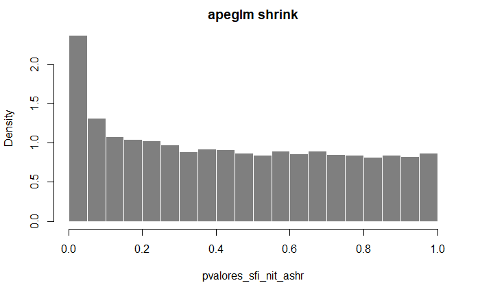

```r
# se quitan los genes cuyas cuentas normalizadas en promedio no llegan a 1 porque añaden ruido
pvalores_sfi_nit_ashr <- sfi_nit_ashr$pvalue[sfi_nit_ashr$baseMean > 1]

hist(pvalores_sfi_nit_ashr, breaks = 0:20/20,
     col = "grey50", border = "white", probability = T,
     main = "apeglm shrink")
```

# Anotación y análisis de expresión

Usando el fold change de 1.5 y el nivel de significación 0.05 los genes diferencialmente expresados son los siguientes:

```r
# corta los nombres a strings de 15, para dejar el nombre de ensembl y que así se pueda localizar con
# mapIds con las keys
ens.str <- substr(rownames(sfi_nit), 1, 15)

columns(org.Hs.eg.db)
```

```
 [1] "ACCNUM"       "ALIAS"        "ENSEMBL"      "ENSEMBLPROT"  "ENSEMBLTRANS" "ENTREZID"     "ENZYME"       "EVIDENCE"     "EVIDENCEALL"  "GENENAME"     "GO"           "GOALL"
[13] "IPI"          "MAP"          "OMIM"         "ONTOLOGY"     "ONTOLOGYALL"  "PATH"         "PFAM"         "PMID"         "PROSITE"      "REFSEQ"       "SYMBOL"       "UCSCKG"
[25] "UNIGENE"      "UNIPROT"
```

```r
sfi_nit_ashr$SYMBOL <- mapIds(org.Hs.eg.db, keys=ens.str, keytype="ENSEMBL", multiVals="first",
                              column="SYMBOL") # la columna que añade
sfi_nit_ashr$ENTREZID <- mapIds(org.Hs.eg.db, keys=ens.str, keytype="ENSEMBL", multiVals="first",
                                column="ENTREZID")
sfi_nit_ashr$GO <- mapIds(org.Hs.eg.db, keys=ens.str, keytype="ENSEMBL", multiVals="first",
                          column="GO")
sfi_nit_ashr$PATH <- mapIds(org.Hs.eg.db, keys=ens.str, keytype="ENSEMBL", multiVals="first",
                            column="PATH")
sfi_nit_ashr$UNIPROT <- mapIds(org.Hs.eg.db, keys=ens.str, keytype="ENSEMBL", multiVals="first",
                               column="UNIPROT")
sfi_nit_ashr$ENZYME <- mapIds(org.Hs.eg.db, keys=ens.str, keytype="ENSEMBL", multiVals="first",
                              column="ENZYME")
```

Ordeno por p-valor y le doy formato de dataframe

```r
sfi_nit_DGE <- as.data.frame(sfi_nit_ashr[order(sfi_nit_ashr$pvalue),])
# tabla con todos los genes
write.csv(as.data.frame(sfi_nit_DGE), file = "resultados/SFI vs NIT/DGE.csv")
```

Hago una tabla aparte con los 353 genes de expresión diferencial.

```r
sfi_nitSig <- as.data.frame(subset(sfi_nit_ashr, padj < alpha & abs(log2FoldChange)>FC)) %>% arrange(-log2FoldChange)
# genes más sobreexpresados
head(sfi_nitSig)
```

|  | baseMean | log2FoldChange | lfcSE | pvalue | padj | SYMBOL | ENTREZID | GO | PATH | UNIPROT | ENZYME |
| --- | --- | --- | --- | --- | --- | --- | --- | --- | --- | --- | --- |
| ENSG00000235896.2 | 75.68341 | 8.298281 | 1.2163482 | 3.787138e-13 | 1.946850e-10 | NA | NA | NA | NA | NA | NA |
| ENSG00000211611.2 | 173.44865 | 8.058933 | 1.1759557 | 3.588837e-13 | 1.910800e-10 | NA | NA | NA | NA | NA | NA |
| ENSG00000242371.1 | 2573.56467 | 8.042711 | 0.9519967 | 1.560168e-18 | 3.876497e-15 | NA | NA | NA | NA | NA | NA |
| ENSG00000211619.2 | 116.38572 | 8.040148 | 1.2425662 | 4.818210e-12 | 1.915463e-09 | NA | NA | NA | NA | NA | NA |
| ENSG00000253274.1 | 93.70213 | 8.006724 | 1.1411616 | 1.179614e-13 | 7.483272e-11 | NA | NA | NA | NA | NA | NA |
| ENSG00000240834.1 | 294.21344 | 7.934872 | 1.0078116 | 1.927818e-16 | 2.612719e-13 | NA | NA | NA | NA | NA | NA |

```r
# genes más subexpresados
tail(sfi_nitSig)
```

|  | baseMean | log2FoldChange | lfcSE | pvalue | padj | SYMBOL | ENTREZID | GO | PATH | UNIPROT | ENZYME |
| --- | --- | --- | --- | --- | --- | --- | --- | --- | --- | --- | --- |
| ENSG00000234965.1 | 11.938072 | 1.534881 | 1.7576544 | 6.778019e-04 | 0.039394430 | SHISA8 | 440829 | NA | NA | A0A087WXQ4 | NA |
| ENSG00000240535.4 | 4.814629 | 1.519835 | 1.6048683 | 5.381508e-04 | 0.033083517 | NA | NA | NA | NA | NA | NA |
| ENSG00000113263.8 | 1018.965483 | 1.513464 | 0.7682544 | 4.393509e-05 | 0.004372194 | ITK | 3702 | GO:0001816 | 04062 | Q08881 | 2.7.10.2 |
| ENSG00000109943.4 | 75.404473 | 1.500387 | 0.8705531 | 7.172396e-05 | 0.006641371 | CRTAM | 56253 | GO:0002355 | NA | O95727 | NA |
| ENSG00000121742.11 | 145.677250 | -2.031379 | 0.8652239 | 3.303482e-05 | 0.003443938 | GJB6 | 10804 | GO:0005829 | NA | A0A024RDS4 | NA |
| ENSG00000188000.2 | 17.578391 | -2.944213 | 1.0904546 | 2.582576e-05 | 0.002779859 | OR7D2 | 162998 | GO:0004930 | 04740 | Q96RA2 | NA |

```r
write.csv(as.data.frame(sfi_nitSig), file = "resultados/SFI vs NIT/DGE_sig.csv")
```

# Análisis de sobrerrepresentación (ORA)

Consiste en un resumen de los procesos en los que más genes de los sobreexpresados y subexpresados intervienen. A continuación se muestran tanto las rutas metabólicas de KEGG como por categorías de GO más representadas. Fuente: https://yulab-smu.github.io/clusterProfiler-book/index.html

```r
# separo los genes
upregulated <- filter(sfi_nitSig, log2FoldChange>FC)
downregulated <- filter(sfi_nitSig, log2FoldChange<(-FC))
# Quito los NAs de EntrezID
upregulated <- upregulated[!is.na(upregulated$ENTREZID),]
downregulated <- downregulated[!is.na(downregulated$ENTREZID),]

nrow(upregulated)
```

```
[1] 96
```

```r
nrow(downregulated)
```

```
[1] 2
```

## GO

```r
upregulated_GO <- enrichGO(upregulated$ENTREZID,
                             OrgDb="org.Hs.eg.db",
                             pvalueCutoff=0.05,
                             qvalueCutoff=0.05,
                             ont = "BP")

upregulated_GO <- setReadable(upregulated_GO, "org.Hs.eg.db", keyType = "ENTREZID")

head(upregulated_GO)
```

|  | ID | Description | GeneRatio | BgRatio | pvalue | p.adjust | qvalue | geneID | Count |
| --- | --- | --- | --- | --- | --- | --- | --- | --- | --- |
| GO:0050851 | GO:0050851 | antigen receptor-mediated signaling pathway | 12/80 | 224/17913 | 3.103409e-10 | 3.643402e-07 | 2.969472e-07 | CD79A/STAP1/MS4A1/FCRL3/LAX1/TRAT1/CD19/CTLA4/HLA-DRB5/KLHL6/HLA-DQA1/ITK | 12 |
| GO:0042100 | GO:0042100 | B cell proliferation | 8/80 | 71/17913 | 9.375240e-10 | 5.503266e-07 | 4.485312e-07 | MZB1/CD79A/TNFRSF13C/MS4A1/FCRL3/CD19/CTLA4/CR2 | 8 |
| GO:0002429 | GO:0002429 | immune response-activating cell surface receptor signaling pathway | 14/80 | 399/17913 | 2.340365e-09 | 9.158628e-07 | 7.464533e-07 | CD79A/STAP1/MS4A1/FCRL3/LAX1/TRAT1/CD19/CTLA4/HLA-DRB5/KLHL6/MUC16/HLA-DQA1/CR2/ITK | 14 |
| GO:0050853 | GO:0050853 | B cell receptor signaling pathway | 7/80 | 53/17913 | 3.542293e-09 | 1.039663e-06 | 8.473538e-07 | CD79A/STAP1/MS4A1/FCRL3/CD19/CTLA4/KLHL6 | 7 |
| GO:0002768 | GO:0002768 | immune response-regulating cell surface receptor signaling pathway | 14/80 | 434/17913 | 6.847417e-09 | 1.607773e-06 | 1.310379e-06 | CD79A/STAP1/MS4A1/FCRL3/LAX1/TRAT1/CD19/CTLA4/HLA-DRB5/KLHL6/MUC16/HLA-DQA1/CR2/ITK | 14 |
| GO:0042113 | GO:0042113 | B cell activation | 10/80 | 215/17913 | 3.984807e-08 | 7.796939e-06 | 6.354719e-06 | MZB1/CD79A/TNFRSF13C/MS4A1/FCRL3/CD28/LAX1/CD19/CTLA4/CR2 | 10 |

```r
downregulated_GO <- enrichGO(downregulated$ENTREZID,
                             OrgDb="org.Hs.eg.db",
                             pvalueCutoff=0.05,
                             qvalueCutoff=0.05,
                             ont = "BP")

downregulated_GO <- setReadable(downregulated_GO, "org.Hs.eg.db", keyType = "ENTREZID")

head(downregulated_GO)
```

|  | ID | Description | GeneRatio | BgRatio | pvalue | p.adjust | qvalue | geneID | Count |
| --- | --- | --- | --- | --- | --- | --- | --- | --- | --- |
| GO:0051602 | GO:0051602 | response to electrical stimulus | 1/2 | 43/17913 | 0.004795354 | 0.04017452 | 0.003132516 | GJB6 | 1 |
| GO:0042471 | GO:0042471 | ear morphogenesis | 1/2 | 115/17913 | 0.012798978 | 0.04017452 | 0.003132516 | GJB6 | 1 |
| GO:0071333 | GO:0071333 | cellular response to glucose stimulus | 1/2 | 128/17913 | 0.014240633 | 0.04017452 | 0.003132516 | GJB6 | 1 |
| GO:0071331 | GO:0071331 | cellular response to hexose stimulus | 1/2 | 130/17913 | 0.014462332 | 0.04017452 | 0.003132516 | GJB6 | 1 |
| GO:0071326 | GO:0071326 | cellular response to monosaccharide stimulus | 1/2 | 131/17913 | 0.014573173 | 0.04017452 | 0.003132516 | GJB6 | 1 |
| GO:0007605 | GO:0007605 | sensory perception of sound | 1/2 | 139/17913 | 0.015459672 | 0.04017452 | 0.003132516 | GJB6 | 1 |

### Términos GO más representados:

```r
p1 <- barplot(upregulated_GO, showCategory = 19) + ggtitle("Categorias GO sobreexpresadas") #○ el 20 tiene un nombre larguísimo
p2 <- barplot(downregulated_GO, showCategory=19) + ggtitle("Categorias GO subexpresadas")

cairo_pdf("resultados/SFI vs NIT/GO barplot.pdf", height = 10, width = 20)
  plot_grid(p1, p2, ncol=2)
dev.off()
```

```r
png("resultados/SFI vs NIT/imagenes/GO barplot.png", height = 1500, width = 2000, res=200)
```

```r
  p1 # los subexpresados no tienen nada especialmente interesante
dev.off()
```

### Redes de términos GO:

```r
cairo_pdf("resultados/SFI vs NIT/upregulated GO network.pdf", height = 10, width = 20)
    cnetplot(upregulated_GO, foldChange=upregulated$log2FoldChange)
dev.off()
```

```r
png("resultados/SFI vs NIT/imagenes/upregulated GO network.png", height = 1500, width = 2000, res=200)
```

```r
  cnetplot(upregulated_GO, foldChange=upregulated$log2FoldChange)
dev.off()
```

```r
cairo_pdf("resultados/SFI vs NIT/downregulated GO network.pdf", height = 10, width = 20)
```

```r
    cnetplot(downregulated_GO, foldChange=upregulated$log2FoldChange)
dev.off()
```

```r
png("resultados/SFI vs NIT/imagenes/downregulated GO network.png", height = 1500, width = 2000, res=200)
```

```r
  cnetplot(downregulated_GO, foldChange=upregulated$log2FoldChange)
dev.off()
```

## KEGG

```r
upregulated_KEGG <- enrichKEGG(gene = upregulated$ENTREZID,
                               organism = 'hsa',
                               pvalueCutoff = 0.05)

upregulated_KEGG <- setReadable(upregulated_KEGG, "org.Hs.eg.db", keyType = "ENTREZID")

head(upregulated_KEGG)
```

|  | ID | Description | GeneRatio | BgRatio | pvalue | p.adjust | qvalue | geneID | Count |
| --- | --- | --- | --- | --- | --- | --- | --- | --- | --- |
| hsa05340 | hsa05340 | Primary immunodeficiency | 6/44 | 38/8040 | 4.569740e-08 | 5.940662e-06 | 4.858355e-06 | CD79A/TNFRSF13B/TNFRSF13C/IGLL1/CD19/IL2RG | 6 |
| hsa04672 | hsa04672 | Intestinal immune network for IgA production | 6/44 | 49/8040 | 2.213490e-07 | 1.438769e-05 | 1.176645e-05 | TNFRSF13B/TNFRSF13C/TNFRSF17/CD28/HLA-DRB5/HLA-DQA1 | 6 |
| hsa04060 | hsa04060 | Cytokine-cytokine receptor interaction | 11/44 | 294/8040 | 3.386918e-07 | 1.467664e-05 | 1.200276e-05 | TNFRSF13B/TNFRSF13C/CXCL10/CXCL9/TNFRSF17/CXCL11/TNFRSF18/CCR4/IL5RA/IL2RG/PRLR | 11 |
| hsa04640 | hsa04640 | Hematopoietic cell lineage | 7/44 | 99/8040 | 9.148096e-07 | 2.973131e-05 | 2.431468e-05 | MS4A1/CD19/CD5/HLA-DRB5/IL5RA/HLA-DQA1/CR2 | 7 |
| hsa05320 | hsa05320 | Autoimmune thyroid disease | 4/44 | 53/8040 | 1.879699e-04 | 4.312004e-03 | 3.526416e-03 | CD28/CTLA4/HLA-DRB5/HLA-DQA1 | 4 |
| hsa04061 | hsa04061 | Viral protein interaction with cytokine and cytokine receptor | 5/44 | 100/8040 | 1.990156e-04 | 4.312004e-03 | 3.526416e-03 | CXCL10/CXCL9/CXCL11/CCR4/IL2RG | 5 |

```r
downregulated_KEGG <- enrichKEGG(gene = downregulated$ENTREZID,
                               organism = 'hsa',
                               pvalueCutoff = 0.05)

downregulated_KEGG <- setReadable(downregulated_KEGG, "org.Hs.eg.db", keyType = "ENTREZID")

head(downregulated_KEGG)
```

| ID | Description | GeneRatio | BgRatio | pvalue | p.adjust | qvalue | geneID | Count |
| --- | --- | --- | --- | --- | --- | --- | --- | --- |

### Rutas KEGG más representadas:

```r
p1 <- barplot(upregulated_KEGG, showCategory = 20) + ggtitle("Rutas KEGG sobreexpresadas")

cairo_pdf("resultados/SFI vs NIT/ KEGG barplot.pdf", height = 10, width = 10)
  p1
dev.off()
```

```r
png("resultados/SFI vs NIT/imagenes/KEGG barplot.png", height = 1500, width = 3000, res=200)
```

```r
  p1
dev.off()
```

### Redes de rutas KEGG:

```r
cairo_pdf("resultados/SFI vs NIT/ upregulated KEGG network.pdf", height = 10, width = 20)
    cnetplot(upregulated_KEGG, foldChange=upregulated$log2FoldChange)
dev.off()
```

```r
png("resultados/SFI vs NIT/imagenes/upregulated KEGG network.png", height = 1500, width = 2000, res=200)
```

```r
  cnetplot(upregulated_KEGG, foldChange=upregulated$log2FoldChange)
dev.off()
```

```r
beepr::beep(3)
```